# Uranium-series decay series

Dr. Ahmad Redaa

2024-10-13

# U-238 Decay Chain

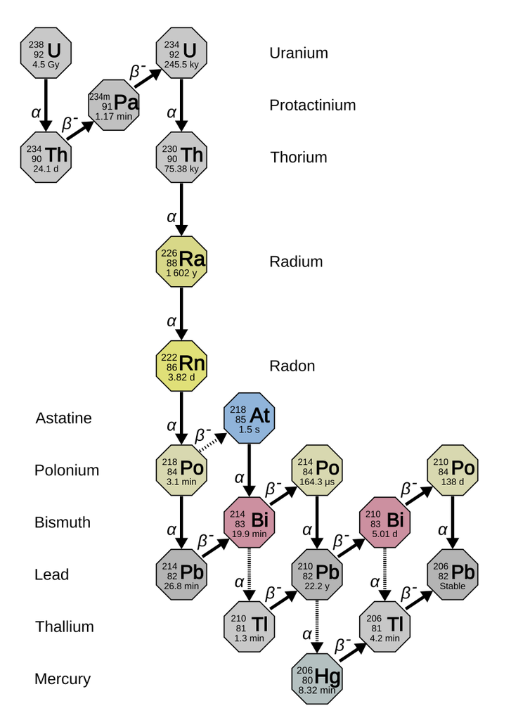

Source: [https://en.wikipedia.org](https://en.m.wikipedia.org/wiki/File:Decay_chain%284n%2B2,_Uranium_series%29.svg)

# U-235 Decay Chain

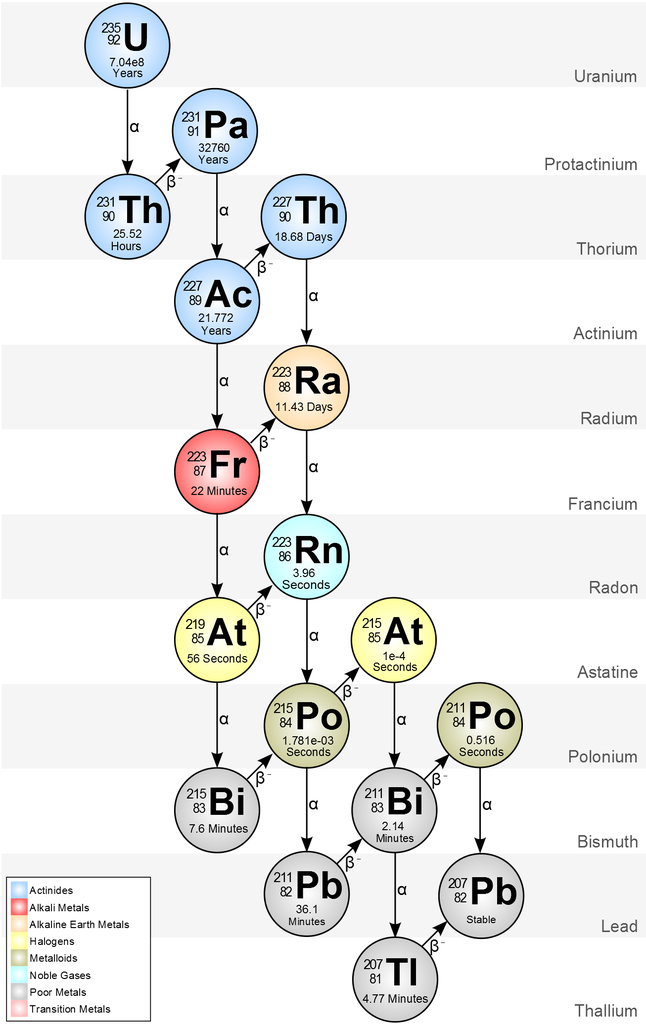

Source: [https://sites.wustl.edu/](https://sites.wustl.edu/hazardouswaste/radionuclides/uranium/)

# Decay Constants and Half-Lives

- Decay constant for $^{238}\text{U}$:
  $$\lambda_{238} = 1.55125 \times 10^{-10} \, \text{year}^{-1}$$
- Decay constant for $^{235}\text{U}$:
  $$\lambda_{235} = 9.8485 \times 10^{-10} \, \text{year}^{-1}$$
- $^{238}\text{U}$ half-life = ~4.5 billion years.
- $^{235}\text{U}$ half-life = ~704 million years.

# Equilibrium in U-Pb Dating

- **Equilibrium** occurs when the radioactive decay chain has fully stabilized.
- In equilibrium, the **production rate** of daughter isotopes (e.g., **$^{206}\text{Pb}$**) equals the **decay rate** of the parent isotopes (e.g., **$^{238}\text{U}$**).

$$\text{Rate of } ^{206}\text{Pb} \text{ production} = \text{Rate of }
^{238}\text{U} \text{ decay}$$

- This state is reached over **geological timescales** (millions of years), making it the basis for U-Pb age calculations in old rocks.

# Disequilibrium in U-Pb Dating

- **Disequilibrium** happens when the system has been disturbed or the chain is not yet stabilized.
- Causes of disequilibrium:
  - Recent **geological events** (e.g., volcanic eruptions, metamorphism).
  - **Leaching** or **mobility** of uranium or lead isotopes (e.g., fluids altering rock chemistry).
- In disequilibrium, the ratio of **parent to daughter isotopes** deviates from that of a stable system.

$$\text{Production rate} \neq \text{Decay rate}$$

# Key reasons for disequilibrium

1. Geological Disturbances
2. Geochemical Mobilization
3. Rapid Formation of Materials
4. Initial Disequilibrium at Formation
5. Selective Loss or Gain of Intermediate Nuclides
6. Surface Weathering and Erosion
7. Insolubility of Intermediate Nuclides

# 1. Geological Disturbances

- **Volcanic eruptions**, **earthquakes**, or **metamorphic events** can disrupt uranium-bearing minerals and cause disequilibrium.
- These disturbances may cause:
  - **Redistribution** or **mobilization** of parent and daughter isotopes.

## Example:

- Volcanic eruptions can mobilize uranium, but thorium may be left behind

# 2. Geochemical Mobilization

- **Leaching** or interaction with **groundwater** and **hydrothermal fluids** can selectively remove or add isotopes.
- **Uranium** is more soluble in water than **thorium**, leading to an imbalance in their decay products.

## Example:

- Groundwater can leach uranium from rocks, while thorium remains behind, disrupting equilibrium in the decay series.

# 3. Rapid Formation of Materials

- **Rapid crystallization** or **mineral precipitation** traps intermediate nuclides before they reach equilibrium.
- Common in environments like **caves** (speleothems) where water chemistry causes fast carbonate formation.

## Example:

- Speleothems can form with an excess of **$^{234}\text{U}$** relative to **$^{238}\text{U}$**.

# 4. Initial Disequilibrium at Formation

- Some minerals form **out of equilibrium** due to their unique chemical properties.
- Common in **igneous minerals** formed in high-temperature environments.

## Example:

- **Zircon** crystals often crystallize with an excess of **$^{230}\text{Th}$** relative to **$^{238}\text{U}$**.

# 5. Selective Loss or Gain of Intermediate Nuclides

- Processes like **alpha-recoil** or **diffusion** can lead to selective loss or gain of isotopes in the decay chain.
- This affects the isotopic balance and results in disequilibrium.

## Example:

- **Alpha-recoil** can physically dislodge an intermediate isotope, disrupting the decay chain.
- NOTE: **Alpha-recoil** refers to the physical displacement of an atom from its position in a mineral or rock lattice as a result of the emission of an alpha particle during radioactive decay, similar to how a gun recoils when firing a bullet.

# 6. Surface Weathering and Erosion

- **Surface processes**, like weathering or erosion, can cause the loss of parent or daughter isotopes.
- Selective leaching of uranium from surface rocks can lead to disequilibrium.

## Example:

- Weathering of uranium-bearing rocks leads to uranium loss, leaving behind an excess of lead isotopes.

# 7. Insolubility of Intermediate Nuclides

- Some intermediate decay products, like **$^{230}\text{Th}$**, are insoluble in water and may be excluded during mineral formation.
- This creates an imbalance in the decay chain.

## Example:

- Carbonate precipitation excludes thorium, causing disequilibrium between uranium and thorium decay products.